# **QnA: Attempting R Programming Sample Questions**

John Karuitha; diakingathia005@gmail.com

Saturday October 22, 2022

## **Background**

In this project, I attempt R programming sample questions available on this [site](https://www.w3resource.com/r-programming-exercises/) https://www.w3resource.com/r-programming-exercises/. The questions range from basic to advanced R programming questions that could come handy in data analysis.

### *Question 1: Write a R program to take input from the user (name and age) and display the values. Also print the version of R installation.*

The function readline() takes a prompt that a user can enter a value. Usually the value is a string. Thus if the input is a number, as.numeric function can do the conversion.

```r
my_name = readline(prompt = "Please enter your name: ")
```

```
## Please enter your name:
```

```r
my_age = readline(prompt = "Please enter your age: ")
```

```
## Please enter your age:
```

```r
print(glue("Hello. My name is {my_name} and I am {my_age} years old."))
```

```
## Hello. My name is  and I am  years old.
```

```r
## To print R version use R.Version()
R.Version()
```

```
## $platform
## [1] "x86_64-pc-linux-gnu"
##
## $arch
## [1] "x86_64"
##
## $os
## [1] "linux-gnu"
##
## $system
## [1] "x86_64, linux-gnu"
##
## $status
## [1] ""
##
## $major
## [1] "4"
##
## $minor
## [1] "2.1"
##
## $year
## [1] "2022"
##
## $month
## [1] "06"
##
## $day
## [1] "23"
##
## $`svn rev`
## [1] "82513"
##
## $language
## [1] "R"
##
## $version.string
## [1] "R version 4.2.1 (2022-06-23)"
##
## $nickname
## [1] "Funny-Looking Kid"
```

### *Question 2: Write a R program to get the details of the objects in memory.*

The ls() function, just like in linux, lists the objects in memory. on the other hand, sessionInfo() lists attached packages.

```r
ls()
```

```
## [1] "my_age"  "my_name"
```

[session information not shown]

### *Question 3: Write a R program to create a sequence of numbers from 20 to 50 and find the mean of numbers from 20 to 60 and sum of numbers from 51 to 91.*

The `:` function is useful in this respect although the `seq` function is also a viable alternative.

```r
my_seq <- 20:50

my_seq
```

```
##  [1] 20 21 22 23 24 25 26 27 28 29 30 31 32 33 34 35 36 37 38 39 40 41 42 43 44
## [26] 45 46 47 48 49 50
```

```r
mean(20:60)
```

```
## [1] 40
```

```r
sum(51:91)
```

```
## [1] 2911
```

### *Question 4: Write a R program to create a vector which contains 10 random integer values between -50 and +50.*

The `sample` function takes the vector of numbers from which to pick a random sample and the size of the sample. The argument `replace` can be TRUE or FALSE depending on the goals of the sampling procedure.

```r
sample(-50:50, size = 10, replace = TRUE)
```

```
##  [1]  28  23  47  26 -18  -7  46   6  32  -9
```

### *Question 5: Write a R program to get the first 10 Fibonacci numbers.*

```r
Fibonacci <- numeric(10)
Fibonacci[1] <- Fibonacci[2] <- 1
for (i in 3:10) Fibonacci[i] <- Fibonacci[i - 2] + Fibonacci[i - 1]
print("First 10 Fibonacci numbers:")
```

```
## [1] "First 10 Fibonacci numbers:"
```

```r
print(Fibonacci)
```

```
##  [1]  1  1  2  3  5  8 13 21 34 55
```

### *Write a R program to print the numbers from 1 to 100 and print “Fizz” for multiples of 3, print “Buzz” for multiples of 5, and print “FizzBuzz” for multiples of both.*

```r
for(number in 1:100){
    if(number %% 3 == 0 & number %% 5 == 0){
        print(glue("{number} FizzBuzz"))
    } else if(number %% 3 == 0){
        print(glue("{number} Fizz"))
    } else if(number %% 5 == 0){
        print(glue("{number} buzz"))
    } else{
        print(glue("{number} Not divisible by 3, 5 or both"))
    }
}
```

```
## 1 Not divisible by 3, 5 or both
## 2 Not divisible by 3, 5 or both
## 3 Fizz
## 4 Not divisible by 3, 5 or both
## 5 buzz
## 6 Fizz
## 7 Not divisible by 3, 5 or both
## 8 Not divisible by 3, 5 or both
## 9 Fizz
## 10 buzz
## 11 Not divisible by 3, 5 or both
## 12 Fizz
## 13 Not divisible by 3, 5 or both
## 14 Not divisible by 3, 5 or both
## 15 FizzBuzz
```

[output cut: 85 more lines]

### *Write a R program to extract first 10 english letter in lower case and last 10 letters in upper case and extract letters between 22nd to 24th letters in upper case.*

```r
letters[1:10]
```

```
##  [1] "a" "b" "c" "d" "e" "f" "g" "h" "i" "j"
```

```r
LETTERS[-(1:10)]
```

```
##  [1] "K" "L" "M" "N" "O" "P" "Q" "R" "S" "T" "U" "V" "W" "X" "Y" "Z"
```

```r
letters[22:24]
```

```
## [1] "v" "w" "x"
```

```r
LETTERS[22:24]
```

```
## [1] "V" "W" "X"
```

### *Write a R program to find the factors of a given number.*

```r
print_factors = function(n) {
print(paste("The factors of",n,"are:"))
for(i in 1:n) {
if((n %% i) == 0) {
print(i)
}
}
}

print_factors(13)
```

```
## [1] "The factors of 13 are:"
## [1] 1
## [1] 13
```

### *Write a R program to find the maximum and the minimum value of a given vector.*

```r
my_vector = c(3, 4, 5, 6, 8)

for(number in my_vector){
    max = my_vector[1]
    if(number > max){
        max = number
    }
}

print(max)
```

```
## [1] 8
```

```r
## or can use the bukt in max function
max(my_vector)
```

```
## [1] 8
```

### *Write a R program to get the unique elements of a given string and unique numbers of vector.*

```r
another_vector <- c(4, 4, 5, 6)

unique(another_vector)
```

```
## [1] 4 5 6
```

### *Write a R program to create three vectors a,b,c with 3 integers. Combine the three vectors to become a 3×3 matrix where each column represents a vector. Print the content of the matrix.*

```r
vector_1 = c(3, 4, 5)
vector_2 = c(5, 4, 7)
vector_3 = c(1, 4, 0)

rbind(vector_1, vector_2, vector_3)
```

```
##          [,1] [,2] [,3]
## vector_1    3    4    5
## vector_2    5    4    7
## vector_3    1    4    0
```

### *Write a R program to create a list of random numbers in normal distribution and count occurrences of each value.*

```r
rnorm(100)
```

```
##   [1]  0.229797664 -1.083330169  0.660683573  0.697206676 -0.286149855
##   [6] -0.943469780 -1.114171204  0.423090310  2.331095199  0.978864161
##  [11] -1.965178680 -0.066296615  0.960096029 -0.473138795  0.254217906
##  [16]  0.886335390  0.602619272 -0.460750973 -1.044790398 -1.207432478
##  [21] -0.349409467 -0.356208824  0.676223362 -1.061193589  0.754876305
##  [26] -0.761029583  1.172117375  0.475989810  0.718548815 -0.185286734
##  [31]  1.425022966 -1.151670919  0.044263129  0.044535567 -1.632704411
##  [36] -1.089987014  0.120048840  1.699171763  1.788594513  0.126073901
##  [41] -0.543527041  0.401447609 -0.245148915 -0.210706058 -0.071019850
##  [46] -0.506909935  0.901672402 -0.067679585  1.256197512  0.364754110
##  [51]  0.035751513 -0.017793342  0.566719525  1.121504592 -0.047844753
##  [56]  0.139193204  0.801084838 -0.214247805 -1.746316105 -0.860466996
##  [61] -0.534074042  1.104428557 -0.975113460 -0.815078420 -0.235829572
##  [66] -0.060242358 -1.153610826  0.391186973  1.544315396 -1.592105512
##  [71] -0.322770384  0.126296695  0.219816407  0.381243621  0.669215084
##  [76] -0.032559950  0.618181096  1.472774428  1.838670870  2.043294632
##  [81]  2.176407495 -0.103793594 -0.316136400 -0.004266685 -0.856487401
##  [86] -0.243075593  0.175576883  0.152535220  0.199489030 -0.869778715
##  [91]  0.566856243  2.153758853  0.264750440 -1.049505155  0.463875285
##  [96] -0.125773076  0.416227379  0.701424545  0.972350542  0.919485909
```

```r
table(rnorm(100))
```

```
##
##   -2.38302201036848   -2.22761630406643   -2.10199588849986   -1.91997304578021
##                   1                   1                   1                   1
##   -1.79070829164414   -1.78508826989895   -1.61906505359522   -1.55458848195854
##                   1                   1                   1                   1
##   -1.51741377555687   -1.25967485866764   -1.24138292641289   -1.22506117520969
##                   1                   1                   1                   1
##   -1.19783783007086   -1.19319058050077   -1.18011361158422   -1.15643041429769
##                   1                   1                   1                   1
##   -1.11665250377174   -1.10433833396181   -1.09562011661831   -1.09195374732825
##                   1                   1                   1                   1
##   -1.07835495226574  -0.999497468421915   -0.99489621152343  -0.846147453981807
##                   1                   1                   1                   1
##  -0.845158455270093  -0.759902086476553  -0.743265452314938  -0.616866885524091
##                   1                   1                   1                   1
##  -0.588220639619837  -0.566940903627769  -0.553267311750096  -0.549476087257181
##                   1                   1                   1                   1
##  -0.539216939681079   -0.50005054806167  -0.468849633981175  -0.458618404249241
##                   1                   1                   1                   1
##  -0.407226985584318  -0.386348491721144  -0.351165467129891  -0.333100505115499
##                   1                   1                   1                   1
##  -0.312628714720446  -0.295669521434038  -0.294901733605946  -0.289979037191058
##                   1                   1                   1                   1
##  -0.229084463600923  -0.222933754435641  -0.204717611465387  -0.194291054690839
##                   1                   1                   1                   1
##   -0.13168340034079  -0.128751436191383 -0.0646696935760001  0.0185446240190189
##                   1                   1                   1                   1
##  0.0318708307517164  0.0533717851727945   0.101675924746025   0.167001623453234
##                   1                   1                   1                   1
##     0.1807384439783   0.203410881535735   0.212001247511726   0.248111408213366
##                   1                   1                   1                   1
##   0.278825189499464   0.284436257207532   0.314147322542787   0.418685560487772
##                   1                   1                   1                   1
##   0.441919608759655   0.477111848464439   0.548215710938542   0.569461549427527
##                   1                   1                   1                   1
##   0.575044762150597   0.610363545320763    0.61243252741164   0.693425157464038
##                   1                   1                   1                   1
##   0.737040487785765   0.771054480748153   0.773785150499026   0.869420917543763
##                   1                   1                   1                   1
##   0.894607823066963   0.934876825530007   0.957897678063635    1.01189087078995
##                   1                   1                   1                   1
##    1.11472083885782    1.11553710880547    1.15365882513663     1.1776608856382
##                   1                   1                   1                   1
##    1.19740267578338    1.22592897958305    1.36492410198976    1.44383717728781
##                   1                   1                   1                   1
##    1.46070114196899    1.52113023481755    1.62662134202109    1.65318438603957
##                   1                   1                   1                   1
##    1.75202648260743    1.85280535800436    1.89233843361191    2.13886839124762
##                   1                   1                   1                   1
##    2.18369035345974     2.2559878856618    2.26561737039207     2.2767919810271
##                   1                   1                   1                   1
```

### *Write a R program to read the .csv file and display the content.*

Here I use a sample of csv files available on this [site](https://people.sc.fsu.edu/~jburkardt/data/csv/csv.html) https://people.sc.fsu.edu/~jburkardt/data/csv/csv.html

```r
my_data <- curl::curl("https://people.sc.fsu.edu/~jburkardt/data/csv/airtravel.csv")

my_csv <- read.csv(my_data)

my_csv
```

```
##    Month X1958 X1959 X1960
## 1    JAN   340   360   417
## 2    FEB   318   342   391
## 3    MAR   362   406   419
## 4    APR   348   396   461
## 5    MAY   363   420   472
## 6    JUN   435   472   535
## 7    JUL   491   548   622
## 8    AUG   505   559   606
## 9    SEP   404   463   508
## 10   OCT   359   407   461
## 11   NOV   310   362   390
## 12   DEC   337   405   432
```

```r
my_csv %>%
    pivot_longer(-Month,
                 names_to = "year",
                 values_to = "passengers") %>%
    relocate(year) %>%
    mutate(year = str_remove_all(year, "X")) %>%
    arrange(year)
```

```
## # A tibble: 36 × 3
##    year  Month passengers
##    <chr> <chr>      <int>
##  1 1958  JAN          340
##  2 1958  FEB          318
##  3 1958  MAR          362
##  4 1958  APR          348
##  5 1958  MAY          363
##  6 1958  JUN          435
##  7 1958  JUL          491
##  8 1958  AUG          505
##  9 1958  SEP          404
## 10 1958  OCT          359
## # … with 26 more rows
```

### *Write a R program to create three vectors numeric data, character data and logical data. Display the content of the vectors and their type.*

```r
double_vector <- c(1, 4, 5)
logical_vector <- c(TRUE, FALSE)
string_vector <- c("Njogu", "paul")

class(double_vector)
```

```
## [1] "numeric"
```

```r
class(logical_vector)
```

```
## [1] "logical"
```

```r
class(string_vector)
```

```
## [1] "character"
```

### *Write a R program to create a 5 x 4 matrix , 3 x 3 matrix with labels and fill the matrix by rows and 2 × 2 matrix with labels and fill the matrix by columns.*

```r
five_by_four <- 1:20

matrix(five_by_four, nrow = 5, byrow = TRUE,
       dimnames = list(c("One", "Two", "Three", "Four", "Five"), c("One", "Two", "Three", "Four")))
```

```
##       One Two Three Four
## One     1   2     3    4
## Two     5   6     7    8
## Three   9  10    11   12
## Four   13  14    15   16
## Five   17  18    19   20
```

```r
three_by_three <- 1:9

matrix(three_by_three, nrow = 3, byrow = TRUE, dimnames = list(c("One", "Two", "Three"), c("One", "Two", "Three")))
```

```
##       One Two Three
## One     1   2     3
## Two     4   5     6
## Three   7   8     9
```

```r
two_by_two <- 1:4

matrix(two_by_two, nrow = 2, byrow = FALSE,
       dimnames = list(c("One", "Two"), c("One", "Two")))
```

```
##     One Two
## One   1   3
## Two   2   4
```

### *Write a R program to create an array, passing in a vector of values and a vector of dimensions. Also provide names for each dimension.*

```r
a =  array(
  6:30,
  dim = c(4, 3, 2),
  dimnames = list(
    c("Col1", "Col2", "Col3", "Col4"),
    c("Row1", "Row2", "Row3"),
    c("Part1", "Part2")
  )
)
print(a)
```

```
## , , Part1
##
##      Row1 Row2 Row3
## Col1    6   10   14
## Col2    7   11   15
## Col3    8   12   16
## Col4    9   13   17
##
## , , Part2
##
##      Row1 Row2 Row3
## Col1   18   22   26
## Col2   19   23   27
## Col3   20   24   28
## Col4   21   25   29
```

### *Write a R program to create an array with three columns, three rows, and two “tables”, taking two vectors as input to the array. Print the array.*

```r
v1 = c(1, 3, 5, 7)
v2 = c(2, 4, 6, 8, 10)
arra1 = array(c(v1, v2),dim = c(3,3,2))
print(arra1)
```

```
## , , 1
##
##      [,1] [,2] [,3]
## [1,]    1    7    6
## [2,]    3    2    8
## [3,]    5    4   10
##
## , , 2
##
##      [,1] [,2] [,3]
## [1,]    1    7    6
## [2,]    3    2    8
## [3,]    5    4   10
```

### *Write a R program to create a list of elements using vectors, matrices and a functions. Print the content of the list.*

```r
list(c(1, 3), matrix(1:4, nrow = 2), mean)
```

```
## [[1]]
## [1] 1 3
##
## [[2]]
##      [,1] [,2]
## [1,]    1    3
## [2,]    2    4
##
## [[3]]
## function (x, ...)
## UseMethod("mean")
## <bytecode: 0x55a1a6c519d0>
## <environment: namespace:base>
```

### *Write a R program to draw an empty plot and an empty plot specify the axes limits of the graphic.*

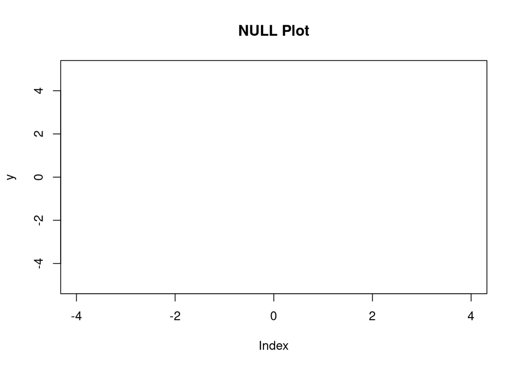

```r
x <- NULL
y = NULL
plot(x, y, xlim = c(-4, 4), ylim = c(-5, 5), main = "NULL Plot")
```

### *Write a R program to create a simple bar plot of five subjects marks.*

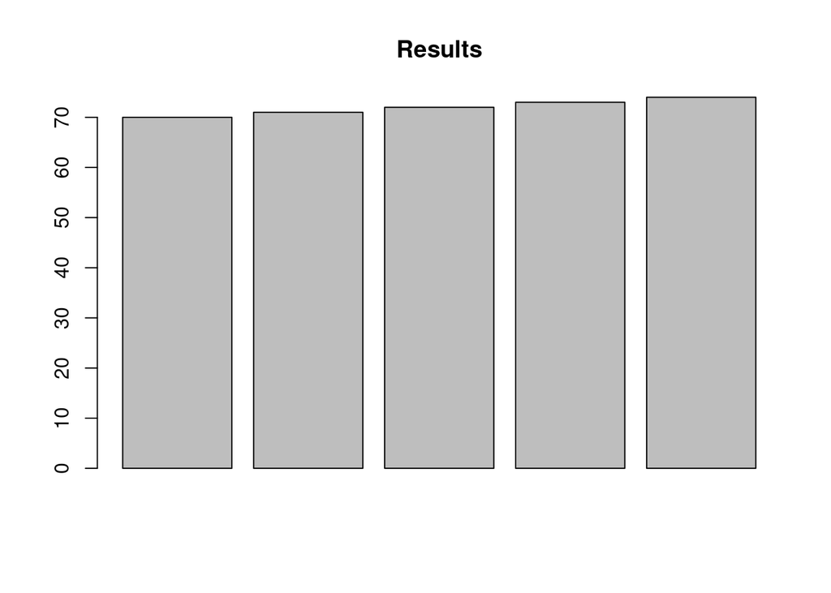

```r
marks = c(70:74)
barplot(marks, main = "Results")
```

### *Write a R program to create bell curve of a random normal distribution.*

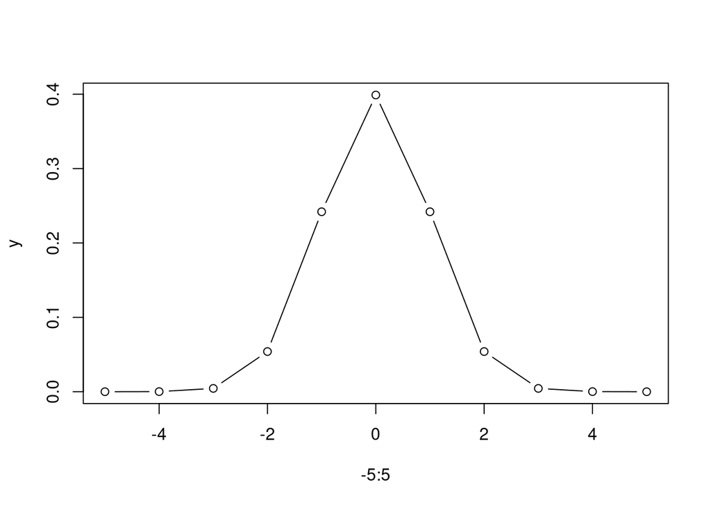

```r
y = dnorm(x = seq(from = -5, to = 5, by = 1))

plot(-5:5, y, type = "both")
```

### *Write a R program to compute sum, mean and product of a given vector elements.*

```r
sum(marks)
```

```
## [1] 360
```

```r
mean(marks)
```

```
## [1] 72
```

```r
prod(marks)
```

```
## [1] 1933051680
```

### *Write a R program to create a list of heterogeneous data, which include character, numeric and logical vectors. Print the lists.*

```r
list(names = c("Jane", "Karuitha"), numerals = 1:4, logic = c(TRUE, FALSE))
```

```
## $names
## [1] "Jane"     "Karuitha"
##
## $numerals
## [1] 1 2 3 4
##
## $logic
## [1]  TRUE FALSE
```

### *Write a R program to create a Dataframes which contain details of 5 employees and display the details.*

```r
my_data <- data.frame(names = c("Jane", "Karuitha"), age = c(19, 33), subject = c("Math", "English"))

summary(my_data)
```

```
##     names                age         subject
##  Length:2           Min.   :19.0   Length:2
##  Class :character   1st Qu.:22.5   Class :character
##  Mode  :character   Median :26.0   Mode  :character
##                     Mean   :26.0
##                     3rd Qu.:29.5
##                     Max.   :33.0
```

### *Write a R program to create the system’s idea of the current date with and without time.*

```r
Sys.Date()
```

```
## [1] "2022-10-22"
```

```r
Sys.time()
```

```
## [1] "2022-10-22 18:19:13 EAT"
```